# Final Project- Bank Marketing Data

December 20, 2018

## Bank Marketing Data Set

- 4120 observations
- 9 numeric, 12 categorical
- Target variable y (Subscribed to a term deposit)

```
##
##  no yes
##   0 316
```

```
##
##   no  yes
## 2568    0
```

```
## Balanced Accuracy
##         0.8589226
```

## Graph

This shows the number of people who did not submit a term deposit

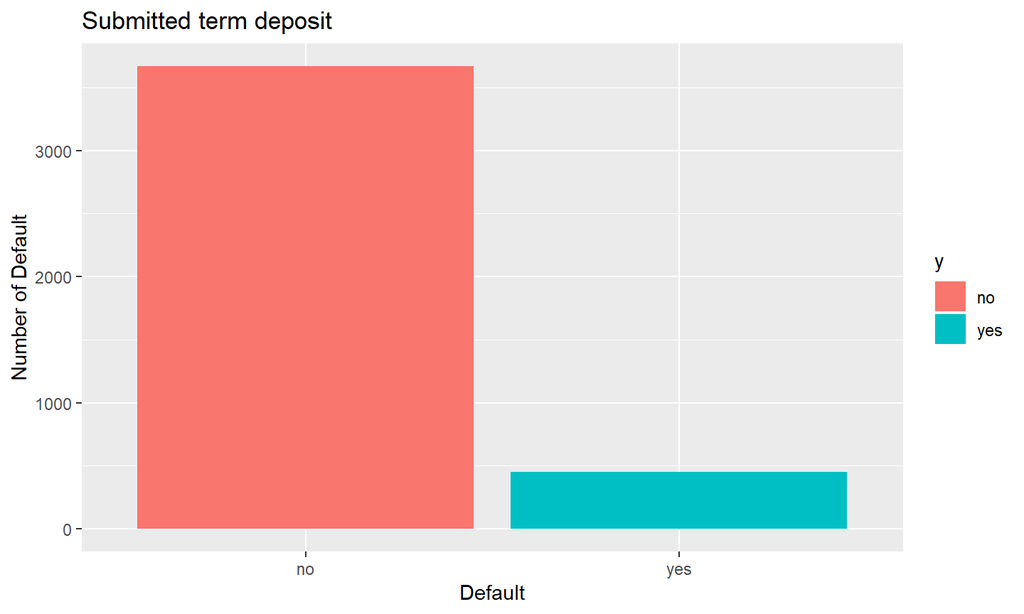

## Graph

This shows that more people between the ages of 30-50 did not submit term deposit

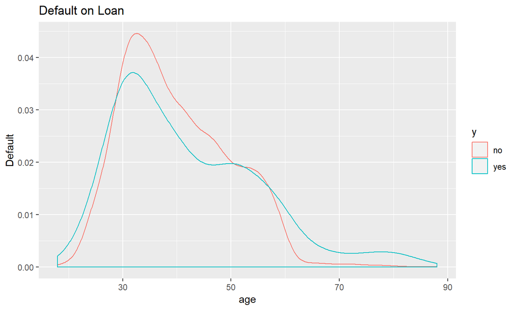

## Graph

This shows that more married people did not submit a term deposit

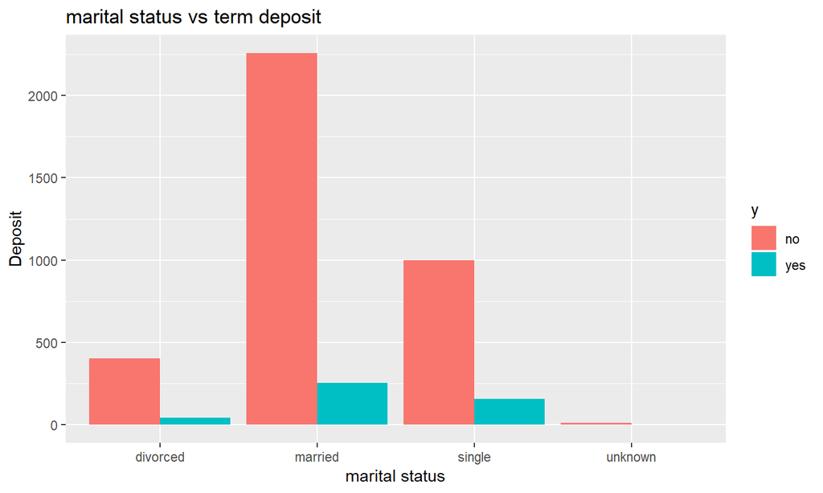

## Graph

This shows that it is pretty even of how many people do or do not submit term deposit in a typical day

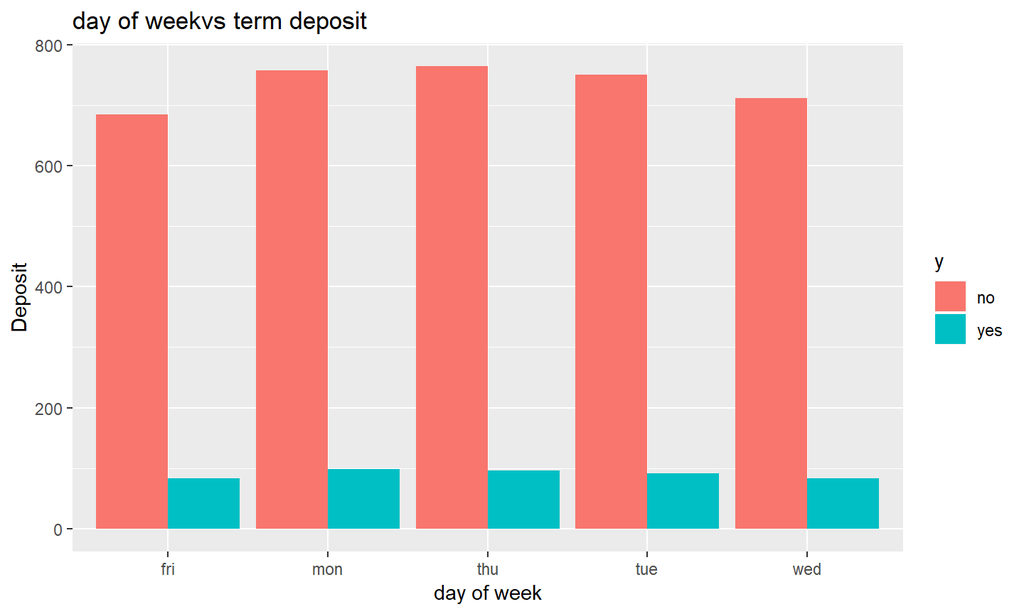

## Graph

There are more people who do not submit a tern deposit in May

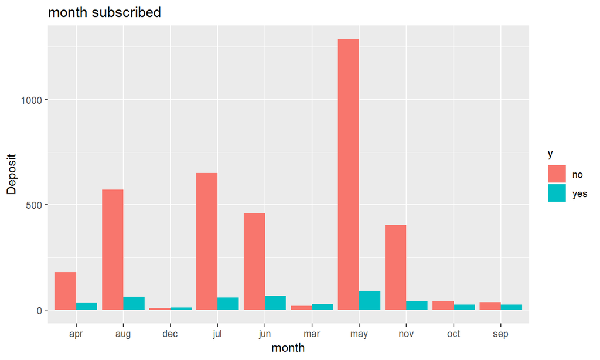

## Graph

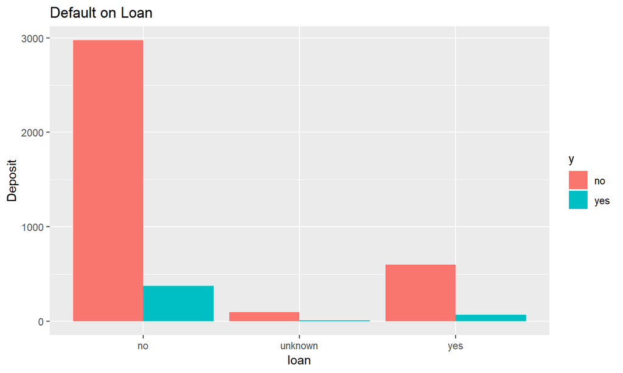

## Graph

This shows how many people who took out a housing loan did not submit a term deposit

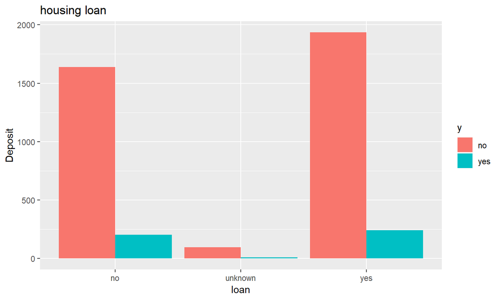

## Graph

The duration in seconds is the amount of time an employee got a hold of the customer over the phone, which shows that more people said yes if the phone call was longer.

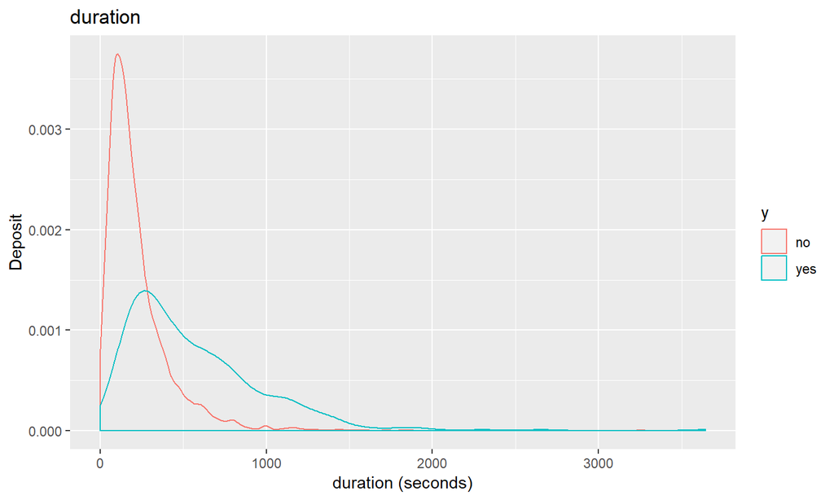

## Graph

This shows that the more times people were contacted, they said no to subscribing to a term deposit.

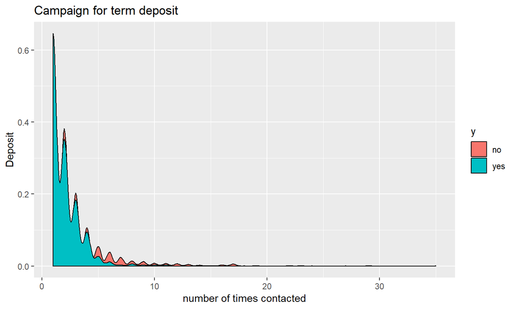

## Graph

This shows that when there were less employees working, more people said yes to a term deposit

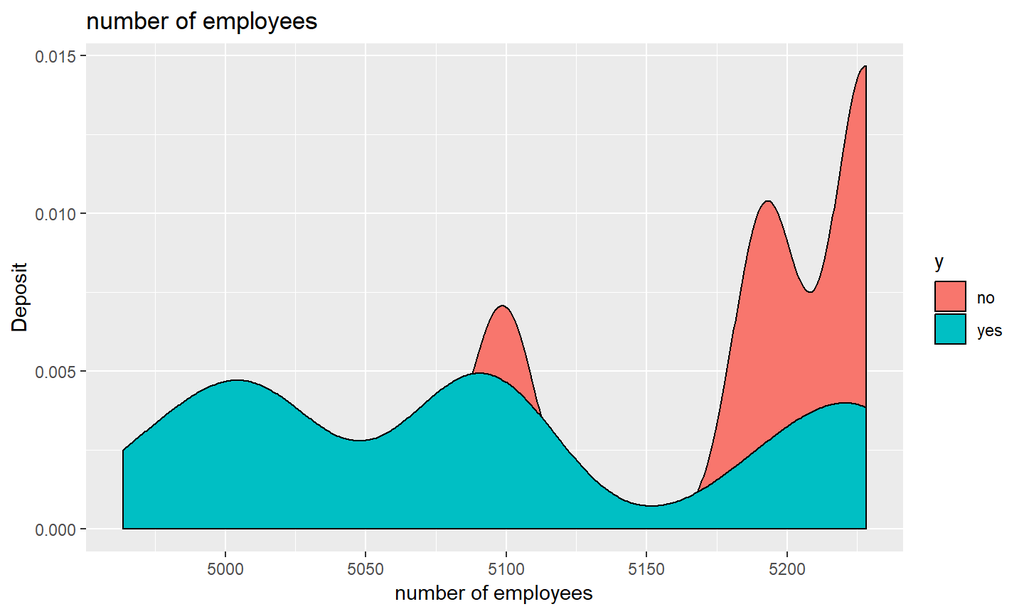

## Graph

There were more people who said no to a term deposit that had a university degree.

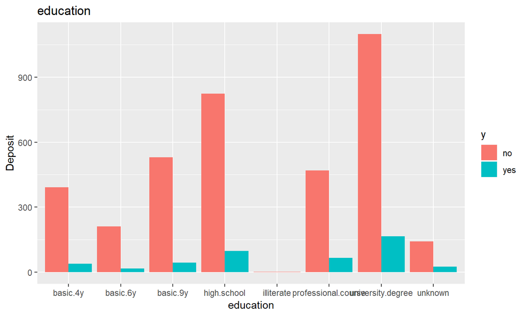

## Graph

People were more likely to say yes to a term deposit if they were contacted earlier

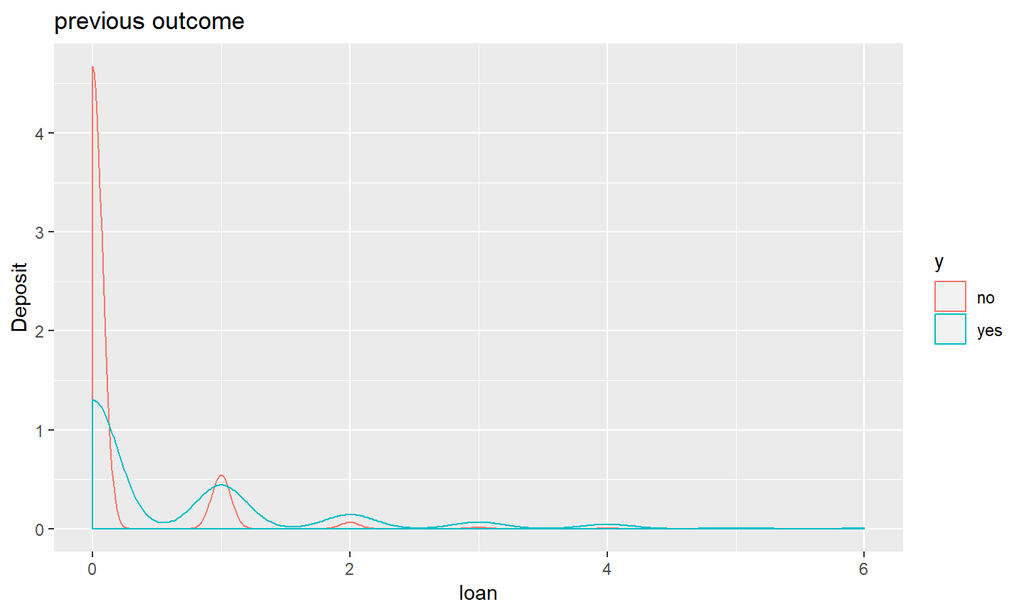

## Graph

There are more people who say yes to a term deposit if they were not contacted before

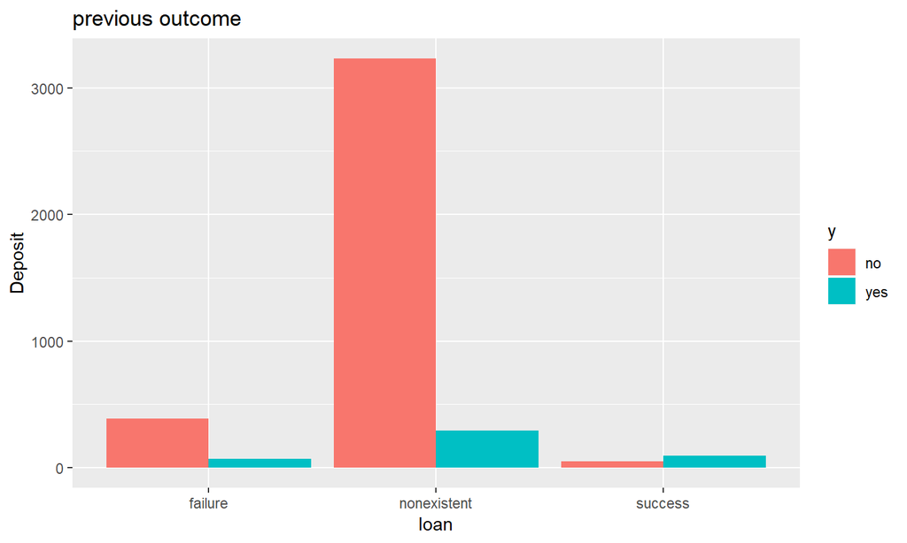

## Handling Missing Values

- Imputing missing values by mean and mode
- Decision Tree

```
## Confusion Matrix and Statistics
##
##           Reference
## Prediction    1    0
##          1 1036   57
##          0   64   78
##
##                Accuracy : 0.902
##                  95% CI : (0.8841, 0.918)
##     No Information Rate : 0.8907
##     P-Value [Acc > NIR] : 0.1079
##
##                   Kappa : 0.508
##  Mcnemar's Test P-Value : 0.5854
##
##             Sensitivity : 0.9418
##             Specificity : 0.5778
##          Pos Pred Value : 0.9478
##          Neg Pred Value : 0.5493
##              Prevalence : 0.8907
##          Detection Rate : 0.8389
##    Detection Prevalence : 0.8850
##       Balanced Accuracy : 0.7598
##
##        'Positive' Class : 1
##
```

## Handling Missing Values

-random forest

```
## Confusion Matrix and Statistics
##
##           Reference
## Prediction    0    1
##          0 1060   66
##          1   40   69
##
##                Accuracy : 0.9142
##                  95% CI : (0.8971, 0.9292)
##     No Information Rate : 0.8907
##     P-Value [Acc > NIR] : 0.003735
##
##                   Kappa : 0.5186
##  Mcnemar's Test P-Value : 0.015173
##
##             Sensitivity : 0.51111
##             Specificity : 0.96364
##          Pos Pred Value : 0.63303
##          Neg Pred Value : 0.94139
##              Prevalence : 0.10931
##          Detection Rate : 0.05587
##    Detection Prevalence : 0.08826
##       Balanced Accuracy : 0.73737
##
##        'Positive' Class : 1
##
```

## Handling Missing Values

```
## Confusion Matrix and Statistics
##
##           Reference
## Prediction    0    1
##          0 1070   72
##          1   30   63
##
##                Accuracy : 0.9174
##                  95% CI : (0.9006, 0.9322)
##     No Information Rate : 0.8907
##     P-Value [Acc > NIR] : 0.001077
##
##                   Kappa : 0.5088
##  Mcnemar's Test P-Value : 4.916e-05
##
##             Sensitivity : 0.46667
##             Specificity : 0.97273
##          Pos Pred Value : 0.67742
##          Neg Pred Value : 0.93695
##              Prevalence : 0.10931
##          Detection Rate : 0.05101
##    Detection Prevalence : 0.07530
##       Balanced Accuracy : 0.71970
##
##        'Positive' Class : 1
##
```

## Handling Missing Values

-glmnet -92.15%

```
## Confusion Matrix and Statistics
##
##           Reference
## Prediction    0    1
##          0 1072   72
##          1   28   63
##
##                Accuracy : 0.919
##                  95% CI : (0.9024, 0.9336)
##     No Information Rate : 0.8907
##     P-Value [Acc > NIR] : 0.0005445
##
##                   Kappa : 0.5148
##  Mcnemar's Test P-Value : 1.708e-05
##
##             Sensitivity : 0.46667
##             Specificity : 0.97455
##          Pos Pred Value : 0.69231
##          Neg Pred Value : 0.93706
##              Prevalence : 0.10931
##          Detection Rate : 0.05101
##    Detection Prevalence : 0.07368
##       Balanced Accuracy : 0.72061
##
##        'Positive' Class : 1
##
```

```
## [1] 1230
```

## Handling Missing Values

- Excluding missing data
- Decision Tree

```
## Confusion Matrix and Statistics
##
##           Reference
## Prediction   1   0
##          1 802  77
##          0  14  34
##
##                Accuracy : 0.9018
##                  95% CI : (0.8808, 0.9202)
##     No Information Rate : 0.8803
##     P-Value [Acc > NIR] : 0.02203
##
##                   Kappa : 0.3831
##  Mcnemar's Test P-Value : 8.066e-11
##
##             Sensitivity : 0.9828
##             Specificity : 0.3063
##          Pos Pred Value : 0.9124
##          Neg Pred Value : 0.7083
##              Prevalence : 0.8803
##          Detection Rate : 0.8652
##    Detection Prevalence : 0.9482
##       Balanced Accuracy : 0.6446
##
##        'Positive' Class : 1
##
```

## Handling Missing Values

- random forest

```
## Confusion Matrix and Statistics
##
##           Reference
## Prediction   0   1
##          0 785  58
##          1  31  53
##
##                Accuracy : 0.904
##                  95% CI : (0.8832, 0.9222)
##     No Information Rate : 0.8803
##     P-Value [Acc > NIR] : 0.012938
##
##                   Kappa : 0.4911
##  Mcnemar's Test P-Value : 0.005851
##
##             Sensitivity : 0.47748
##             Specificity : 0.96201
##          Pos Pred Value : 0.63095
##          Neg Pred Value : 0.93120
##              Prevalence : 0.11974
##          Detection Rate : 0.05717
##    Detection Prevalence : 0.09061
##       Balanced Accuracy : 0.71974
##
##        'Positive' Class : 1
##
```

## Handling Missing Values

- glm
- 90.94%

```
## Confusion Matrix and Statistics
##
##           Reference
## Prediction   0   1
##          0 791  63
##          1  25  48
##
##                Accuracy : 0.9051
##                  95% CI : (0.8844, 0.9232)
##     No Information Rate : 0.8803
##     P-Value [Acc > NIR] : 0.009749
##
##                   Kappa : 0.4715
##  Mcnemar's Test P-Value : 8.006e-05
##
##             Sensitivity : 0.43243
##             Specificity : 0.96936
##          Pos Pred Value : 0.65753
##          Neg Pred Value : 0.92623
##              Prevalence : 0.11974
##          Detection Rate : 0.05178
##    Detection Prevalence : 0.07875
##       Balanced Accuracy : 0.70090
##
##        'Positive' Class : 1
##
```

## Handling Missing Values

- glmnet
- 91.15%

```
## Confusion Matrix and Statistics
##
##           Reference
## Prediction   0   1
##          0 793  60
##          1  23  51
##
##                Accuracy : 0.9105
##                  95% CI : (0.8902, 0.9281)
##     No Information Rate : 0.8803
##     P-Value [Acc > NIR] : 0.001987
##
##                   Kappa : 0.5038
##  Mcnemar's Test P-Value : 7.766e-05
##
##             Sensitivity : 0.45946
##             Specificity : 0.97181
##          Pos Pred Value : 0.68919
##          Neg Pred Value : 0.92966
##              Prevalence : 0.11974
##          Detection Rate : 0.05502
##    Detection Prevalence : 0.07983
##       Balanced Accuracy : 0.71564
##
##        'Positive' Class : 1
##
```

## Recoding categorical variables

```r
#recoding categorical variables
bank4=bank3
Spring.set=c("mar","apr","may")
Summer.set=c("jun","jul","aug")
Autumn.set=c("sep","oct","nov")
Winter.set=c("dec")
bank4$month=recode(bank4$month,"Spring.set='Spring'; Summer.set='Summer'; Autumn.set='Autumn'; Winter.set='Winter'")
levels(bank4$job)=c("low class", "low class", "high class", "low class", "high class", "unemployed", "low class", "low class", "low class", "low class", "unemployed", "unknown")
levels(bank4$education)=c("before high school","before high school", "before high school", "high school", "before high school", "unknown", "college", "unknown")
```

## Recoding categorical variables

- decision tree

```
## Confusion Matrix and Statistics
##
##           Reference
## Prediction   1   0
##          1 802  77
##          0  14  34
##
##                Accuracy : 0.9018
##                  95% CI : (0.8808, 0.9202)
##     No Information Rate : 0.8803
##     P-Value [Acc > NIR] : 0.02203
##
##                   Kappa : 0.3831
##  Mcnemar's Test P-Value : 8.066e-11
##
##             Sensitivity : 0.9828
##             Specificity : 0.3063
##          Pos Pred Value : 0.9124
##          Neg Pred Value : 0.7083
##              Prevalence : 0.8803
##          Detection Rate : 0.8652
##    Detection Prevalence : 0.9482
##       Balanced Accuracy : 0.6446
##
##        'Positive' Class : 1
##
```

## Recoding categorical variables

- random forest

```
## Confusion Matrix and Statistics
##
##           Reference
## Prediction   0   1
##          0 786  54
##          1  30  57
##
##                Accuracy : 0.9094
##                  95% CI : (0.889, 0.9271)
##     No Information Rate : 0.8803
##     P-Value [Acc > NIR] : 0.002798
##
##                   Kappa : 0.5259
##  Mcnemar's Test P-Value : 0.012090
##
##             Sensitivity : 0.51351
##             Specificity : 0.96324
##          Pos Pred Value : 0.65517
##          Neg Pred Value : 0.93571
##              Prevalence : 0.11974
##          Detection Rate : 0.06149
##    Detection Prevalence : 0.09385
##       Balanced Accuracy : 0.73837
##
##        'Positive' Class : 1
##
```

## Recoding categorical variables

```
## Confusion Matrix and Statistics
##
##           Reference
## Prediction   0   1
##          0 794  62
##          1  22  49
##
##                Accuracy : 0.9094
##                  95% CI : (0.889, 0.9271)
##     No Information Rate : 0.8803
##     P-Value [Acc > NIR] : 0.002798
##
##                   Kappa : 0.4909
##  Mcnemar's Test P-Value : 2.088e-05
##
##             Sensitivity : 0.44144
##             Specificity : 0.97304
##          Pos Pred Value : 0.69014
##          Neg Pred Value : 0.92757
##              Prevalence : 0.11974
##          Detection Rate : 0.05286
##    Detection Prevalence : 0.07659
##       Balanced Accuracy : 0.70724
##
##        'Positive' Class : 1
##
```

## Recoding Categorical Variables

- glmnet
- 91.48%

```
## Confusion Matrix and Statistics
##
##           Reference
## Prediction   0   1
##          0 793  62
##          1  23  49
##
##                Accuracy : 0.9083
##                  95% CI : (0.8879, 0.9261)
##     No Information Rate : 0.8803
##     P-Value [Acc > NIR] : 0.003891
##
##                   Kappa : 0.4872
##  Mcnemar's Test P-Value : 3.761e-05
##
##             Sensitivity : 0.44144
##             Specificity : 0.97181
##          Pos Pred Value : 0.68056
##          Neg Pred Value : 0.92749
##              Prevalence : 0.11974
##          Detection Rate : 0.05286
##    Detection Prevalence : 0.07767
##       Balanced Accuracy : 0.70663
##
##        'Positive' Class : 1
##
```

## Encoding Categorical Variables

- dummy coding
- decision tree

```
## Confusion Matrix and Statistics
##
##           Reference
## Prediction   1   0
##          1 802  77
##          0  14  34
##
##                Accuracy : 0.9018
##                  95% CI : (0.8808, 0.9202)
##     No Information Rate : 0.8803
##     P-Value [Acc > NIR] : 0.02203
##
##                   Kappa : 0.3831
##  Mcnemar's Test P-Value : 8.066e-11
##
##             Sensitivity : 0.9828
##             Specificity : 0.3063
##          Pos Pred Value : 0.9124
##          Neg Pred Value : 0.7083
##              Prevalence : 0.8803
##          Detection Rate : 0.8652
##    Detection Prevalence : 0.9482
##       Balanced Accuracy : 0.6446
##
##        'Positive' Class : 1
##
```

## Encoding Categorical Variables

- random forest

```
## Confusion Matrix and Statistics
##
##           Reference
## Prediction   0   1
##          0 785  58
##          1  31  53
##
##                Accuracy : 0.904
##                  95% CI : (0.8832, 0.9222)
##     No Information Rate : 0.8803
##     P-Value [Acc > NIR] : 0.012938
##
##                   Kappa : 0.4911
##  Mcnemar's Test P-Value : 0.005851
##
##             Sensitivity : 0.47748
##             Specificity : 0.96201
##          Pos Pred Value : 0.63095
##          Neg Pred Value : 0.93120
##              Prevalence : 0.11974
##          Detection Rate : 0.05717
##    Detection Prevalence : 0.09061
##       Balanced Accuracy : 0.71974
##
##        'Positive' Class : 1
##
```

## Encoding Categorical Variables

- glm
- 90.94%

```
## Confusion Matrix and Statistics
##
##           Reference
## Prediction   0   1
##          0 791  63
##          1  25  48
##
##                Accuracy : 0.9051
##                  95% CI : (0.8844, 0.9232)
##     No Information Rate : 0.8803
##     P-Value [Acc > NIR] : 0.009749
##
##                   Kappa : 0.4715
##  Mcnemar's Test P-Value : 8.006e-05
##
##             Sensitivity : 0.43243
##             Specificity : 0.96936
##          Pos Pred Value : 0.65753
##          Neg Pred Value : 0.92623
##              Prevalence : 0.11974
##          Detection Rate : 0.05178
##    Detection Prevalence : 0.07875
##       Balanced Accuracy : 0.70090
##
##        'Positive' Class : 1
##
```

## Encoding Categorical Variables

```
## Confusion Matrix and Statistics
##
##           Reference
## Prediction   0   1
##          0 793  60
##          1  23  51
##
##                Accuracy : 0.9105
##                  95% CI : (0.8902, 0.9281)
##     No Information Rate : 0.8803
##     P-Value [Acc > NIR] : 0.001987
##
##                   Kappa : 0.5038
##  Mcnemar's Test P-Value : 7.766e-05
##
##             Sensitivity : 0.45946
##             Specificity : 0.97181
##          Pos Pred Value : 0.68919
##          Neg Pred Value : 0.92966
##              Prevalence : 0.11974
##          Detection Rate : 0.05502
##    Detection Prevalence : 0.07983
##       Balanced Accuracy : 0.71564
##
##        'Positive' Class : 1
##
```

## Best Model?

```
## Confusion Matrix and Statistics
##
##           Reference
## Prediction    0    1
##          0 1072   79
##          1   28   56
##
##                Accuracy : 0.9134
##                  95% CI : (0.8963, 0.9285)
##     No Information Rate : 0.8907
##     P-Value [Acc > NIR] : 0.004975
##
##                   Kappa : 0.4667
##  Mcnemar's Test P-Value : 1.34e-06
##
##             Sensitivity : 0.41481
##             Specificity : 0.97455
##          Pos Pred Value : 0.66667
##          Neg Pred Value : 0.93136
##              Prevalence : 0.10931
##          Detection Rate : 0.04534
##    Detection Prevalence : 0.06802
##       Balanced Accuracy : 0.69468
##
##        'Positive' Class : 1
##
```

## Conclusion

- glmnet model by imputing with mean and mode is the best performing model